# Bayesian modeling of room-acoustic memory with same and different speech signals

Analysis Script with figures for publication

Sergio de las Heras

This RMarkdown script reproduces the analysis of Experiment 2. It produces the figures that appear in the publication.

This script is meant to be knitted from its own folder (`code/experiment2`), so all paths are relative to it.

# Setup

The figures use the Latin Modern Roman font if it is installed, and the default serif font otherwise. The package `sdlhRTools` provides `geom_violinhist()`, used in the descriptive plots.

```r
library(tidyverse)
library(patchwork)
library(rstan)
library(bayesplot)
library(tidybayes)
library(tm)
library(sdlhRTools)

# Set to TRUE to overwrite the figures in doc/figs
savePlots <- FALSE

# Set to TRUE to fit the Stan models again instead of loading the saved fits
refit <- FALSE

dataDir <- "../../data"
figDir  <- "../../doc/figs"
stanDir <- "stan"


# STAN FIT
# Use multicore if possible and autosave the compiled Stan programs
options(mc.cores = parallel::detectCores())
rstan_options(auto_write = TRUE)

set.seed(123)

# PLOTS
# Use Latin Modern Roman when it is installed, otherwise default to serif font
hasPaperFont <- "LMRoman10-Regular" %in% systemfonts::system_fonts()$name
paperFont <- if (hasPaperFont) "LM Roman 10" else "serif"

if (hasPaperFont && capabilities("aqua")) {
  quartzFonts(`LM Roman 10` = quartzFont(
    paste0("LMRoman10-", c("Regular", "Bold", "Italic", "BoldItalic"))
  ))
}

# Common theme of the paper figures
theme_paper <- function(base_size = 10) {
  theme_minimal(base_family = paperFont, base_size = base_size)
}

speechColours <- c("Same speech" = "#548665", "Different speech" = "#BD7A3B")

# Save a figure to doc/figs (sizes in cm), only when savePlots is TRUE.
savePaperFig <- function(plot, file, width, height) {
  if (savePlots) {
    ggsave(file.path(figDir, file), plot = plot,
           width = width, height = height, units = "cm",
           device = if (capabilities("aqua")) {
             function(filename, ...) quartz(type = "pdf", file = filename, ...)
           } else {
             cairo_pdf
           })
  }
}
```

# Data

The experiment data are in two files:

- `experimentResults.csv`: one row per trial, with the columns
  - `ParticipantID`, `SetNo`: participant ID and set (1 to 3),
  - `SpeakerCondition`: same speech (`SS`) or different speech (`DS`),
  - `Communities`: room communities of the two rooms of the trial (`A`, `B`, `C`, or a pair such as `A-B`),
  - `RoomCondition`: same room (`SR`) or different rooms (`DR`),
  - `deltaT`: retention interval in seconds,
  - `RoomA`, `RoomB`: identifiers of the rooms of the first and second sound,
  - `AudioA`, `AudioB`: speech samples of the first and second sound,
  - `T20A`, `T20B`: mid-frequency reverberation time of the two rooms in seconds,
  - `Response`: answer of the participant, same room (`SR`) or different rooms (`DR`),
  - `isSame`: 1 if both sounds were in the same room,
  - `saySame`: 1 if the participant answered “same room”,
  - `correctFlag`, `type`: whether the answer was correct, and its signal detection category (`hit`, `miss`, `fa`, `cr`),
  - `Attr1`–`Attr4`: optional free-text attributes given by the participant.
- `surveys.csv`: one row per participant with the answers to the questionnaires.

```r
attrCols <- c("Attr1", "Attr2", "Attr3", "Attr4")

data <- read.csv(file.path(dataDir, "experimentResults.csv")) %>%
  mutate(
    sameSpeaker   = ifelse(SpeakerCondition == "DS", 0, 1),
    hasAttributes = rowSums(!is.na(across(all_of(attrCols)))) > 0
  )

surveyData <- read.csv(file.path(dataDir, "surveys.csv"))

tibble(
  participants = n_distinct(data$ParticipantID),
  trials       = nrow(data)
)
```

```
## # A tibble: 1 × 2
##   participants trials
##          <int>  <int>
## 1           50   7795
```

## Participants

Summary and demographic data.

```r
surveyData %>% count(Gender)
```

```
##   Gender  n
## 1 female 17
## 2   male 33
```

```r
surveyData %>%
  summarize(
    Age.mean   = mean(Age, na.rm = TRUE),
    Age.median = median(Age, na.rm = TRUE),
    Age.sd     = sd(Age, na.rm = TRUE),
    across(
      c(focus01, focus02, focus03,
        confidence01, confidence02, confidence03,
        AcouTraining, AcouResearch,
        ListeningTestExperience, Difficulty),
      list(mean = ~ mean(.x, na.rm = TRUE),
           sd   = ~ sd(.x, na.rm = TRUE)),
      .names = "{.col}.{.fn}"
    )
  ) %>%
  pivot_longer(everything(), names_to = "Statistic", values_to = "Value") %>%
  knitr::kable(digits = 2, align = "lr", caption = "Survey summary")
```

Survey summary

| Statistic | Value |
| --- | --- |
| Age.mean | 28.56 |
| Age.median | 26.50 |
| Age.sd | 7.91 |
| focus01.mean | 7.58 |
| focus01.sd | 1.25 |
| focus02.mean | 6.70 |
| focus02.sd | 1.43 |
| focus03.mean | 6.20 |
| focus03.sd | 1.43 |
| confidence01.mean | 6.60 |
| confidence01.sd | 1.43 |
| confidence02.mean | 6.38 |
| confidence02.sd | 1.55 |
| confidence03.mean | 6.18 |
| confidence03.sd | 1.38 |
| AcouTraining.mean | 3.38 |
| AcouTraining.sd | 5.32 |
| AcouResearch.mean | 2.42 |
| AcouResearch.sd | 4.40 |
| ListeningTestExperience.mean | 0.60 |
| ListeningTestExperience.sd | 0.29 |
| Difficulty.mean | 0.57 |
| Difficulty.sd | 0.20 |

Strategy that each participant reported for the task (free text).

```r
surveyData %>% select(ParticipantID, Approach)
```

```
##    ParticipantID
## 1              1
## 2              2
## 3              3
## 4              4
## 5              5
## 6              6
## 7              7
## 8              8
## 9              9
## 10            10
## 11            11
## 12            12
## 13            13
## 14            14
```

[output cut: 87 more lines]

## Attributes

Participants could describe with up to four words what changed between the two sounds. The words are spelled freely, so variants and typos of the same concept are first mapped to one category with the dictionary below. Then punctuation, numbers and stop words are removed, and the categories are counted.

```r
text_data <- unlist(lapply(data[c("Attr1", "Attr2", "Attr3", "Attr4")], function(x) {
  x <- x[!is.na(x) & x != ""]
  as.character(x)
}))

dict <- list(
  reverberation = c(
    "reverb","rev","reverberant","reverberation","reverberance",
    "reverbration","reverbrant","revberant","reverbery","reverbs",
    "reverbe","reveberant","rverb","reverbrant","rt","rt60","t60","revertb","reberb"
  ),
  echo = c(
    "echoy","echo","echoes","eco","pong","pingpong","ping","kaiku"
  ),
  room = c("room","roomy","roomier","space","spatial","spacious","acoustic","acoustics","acustic"),
  dry = c("dry","drier","dryer","dryness"),
  wet = c("wet","wetter"),
  loudness = c("loud","louder","loudness","quieter","softer","volume","level","intensity"),
  brightness = c("brightness","bright","brighter","darker","high","higher","higer","low","lower","llower","colder","warmer","warm","open","full","fuller","richer"),
  timbre = c(
    "timbre","tone","tonal","tonality","color","colour","coloration","colouration",
    "timbefr","colorisation","muffled", "mufffled", "muffle","muted","metallic","hollow","hollowness"
  ),
  distance = c(
    "distance","far","farther","further","away","distant","near","nearer","closer","coser","distamce","proximity"
  ),
  direction = c("direction","directional","left","right","panning","side","behind","towards","orientation"),
  localization = c("location", "lcation", "localization","localised","local","loc","locaization","llocal","position","placement","centered"
  ),
  size = c("size","smaller","bigger","larger","width","wider","massive","huge","smaler","lager"),
  decay = c("decay","tail","tails","longer","shorter","shjorter","shrter","loger","duration","time","length"),
  drr = c("drr","ratio","direct"),
  resonance = c("resonance","resonant","resonances","ressonance","ringing","modes","mode","modal"),
  clarity = c("clarity","clear","clearer","crisp","sharp","sharper","blurrier","focused","focus","intelligibility","intellegibility","intellgibility"),
  bass = c("bass","bassier","boomy","boomier","mids", "bommy"),
  earlyreflections = c("reflections","reflection","refections"),
  stereo = c("stereo","stero","image","enveloping"),
  source = c("source","speaker","voice","mic","listener", "osurce","souce"),
  frequency = c("frequency","freq","freqs","frequncy","spectrum","spectral"),
  diffuseness = c("diffused","diffuseness","difuseness","diffusedness"),
  combfiltering = c("combfiltered","combfilterin","combfiter"),
  damping = c("damping","damped","dampened","attenuation","absorbed"),
  change = c(
    "different","difference","diff","diffe","differet","differnt","diffrent","diiferent",
    "changed","change","seems","seemed","slightly","slighty","sightly","slighlty",
    "sliightly","sllightly","slughtly","sighlty"
  )
)

map_words <- content_transformer(function(x) {
  for (k in names(dict)) {
    pattern <- paste0("\\b(", paste(dict[[k]], collapse = "|"), ")\\b")
    x <- gsub(pattern, k, x, perl = TRUE)
  }
  x
})

custom_stop <- c("one","bit","much","second","2nd","2ndone","1st","2ns","two","way","maybe","think","felt","feeling","feels","good","just", "also", "change", "less")


corpus <- VCorpus(VectorSource(text_data)) %>%
  tm_map(content_transformer(tolower)) %>%
  tm_map(content_transformer(function(x) gsub("[[:punct:]]+", " ", x))) %>%
  tm_map(map_words) %>%
  tm_map(removeNumbers) %>%
  tm_map(removeWords, c(stopwords("en"), custom_stop)) %>%
  tm_map(stripWhitespace)

dtm <- DocumentTermMatrix(corpus)

attribute_freq <- tibble(
  attribute = colnames(dtm),
  count     = colSums(as.matrix(dtm))
) %>%
  arrange(desc(count))

head(attribute_freq, 10)
```

```
## # A tibble: 10 × 2
##    attribute     count
##    <chr>         <dbl>
##  1 reverberation   748
##  2 distance        282
##  3 size            266
##  4 decay           263
##  5 localization    247
##  6 timbre          240
##  7 dry             192
##  8 loudness        184
##  9 direction       136
## 10 room            133
```

## General performance

Overall performance is the proportion of correct answers of each participant across all trials of the experiment, summarised across participants.

```r
participantPerformance <- data %>%
  group_by(ParticipantID) %>%
  summarise(propCorrect = mean(correctFlag), nTrials = n())

participantPerformance %>%
  summarise(
    mean   = mean(propCorrect),
    median = median(propCorrect),
    sd     = sd(propCorrect),
    min    = min(propCorrect),
    max    = max(propCorrect)
  )
```

```
## # A tibble: 1 × 5
##    mean median     sd   min   max
##   <dbl>  <dbl>  <dbl> <dbl> <dbl>
## 1 0.721  0.718 0.0673 0.577 0.885
```

### Performance by set

Each participant did three sets of trials. The proportion of correct answers is computed per participant and set.

```r
setPerformance <- data %>%
  group_by(ParticipantID, SetNo) %>%
  summarise(propCorrect = mean(correctFlag), .groups = "drop") %>%
  mutate(SetNo = factor(SetNo, labels = paste("Set", 1:3)))

setPerformance %>%
  group_by(SetNo) %>%
  summarise(
    mean = mean(propCorrect),
    sd   = sd(propCorrect),
    N    = n()
  )
```

```
## # A tibble: 3 × 4
##   SetNo  mean     sd     N
##   <fct> <dbl>  <dbl> <int>
## 1 Set 1 0.728 0.0822    50
## 2 Set 2 0.722 0.0747    50
## 3 Set 3 0.715 0.0916    50
```

The figure shows, per set and over all sets, the distribution of the participants’ proportions of correct answers: a half violin with a histogram, a boxplot, and the mean (diamond).

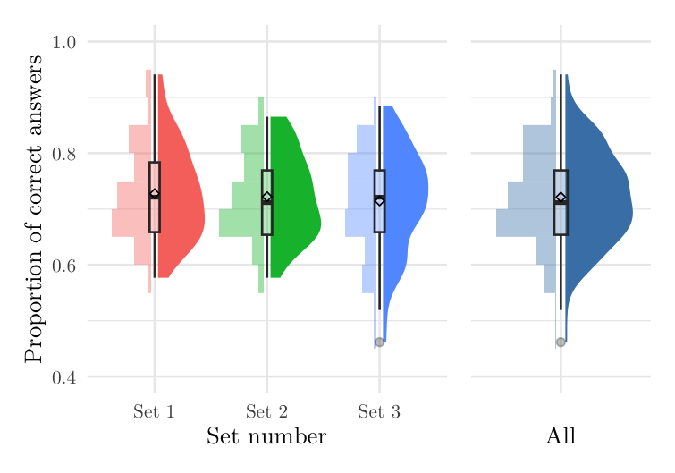

```r
# Layers shared by the performance figures
performanceLayers <- list(
  geom_violinhist(scale = "area", nudge_value = 0.03, binwidth = 0.05),
  geom_boxplot(width = 0.09, alpha = 0.3),
  stat_summary(geom = "point", fun = "mean", size = 1, shape = 5),
  ylim(0.4, 1),
  theme_paper(),
  theme(legend.position = "none")
)

bySetPlot <- ggplot(setPerformance, aes(x = SetNo, y = propCorrect, fill = SetNo)) +
  performanceLayers +
  labs(x = "Set number", y = "Proportion of correct answers")

allSetsPlot <- ggplot(setPerformance, aes(x = "", y = propCorrect, fill = "All")) +
  performanceLayers +
  scale_fill_manual(values = c(All = "steelblue")) +
  labs(x = "All", y = NULL) +
  theme(axis.text.y = element_blank())

propCorrectFig <- bySetPlot + allSetsPlot + plot_layout(widths = c(2, 1))

propCorrectFig
```

```r
savePaperFig(propCorrectFig, "exp2_propCorrect.pdf", width = 10, height = 7)
```

### Performance by retention interval

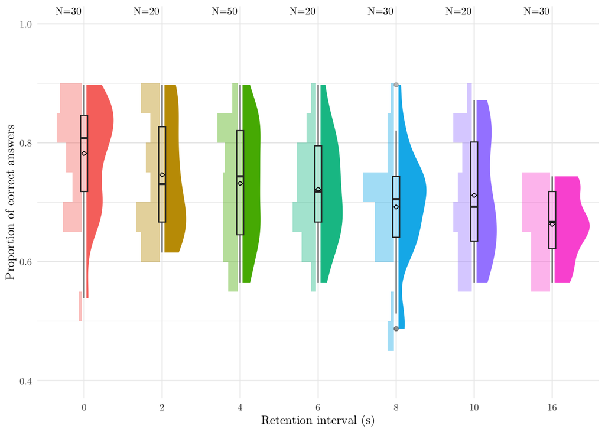

```r
timePerformance <- data %>%
  group_by(ParticipantID, deltaT) %>%
  summarise(propCorrect = mean(correctFlag), .groups = "drop") %>%
  group_by(deltaT) %>%
  mutate(N = n()) %>%
  ungroup() %>%
  mutate(deltaT = factor(deltaT))

ggplot(timePerformance, aes(x = deltaT, y = propCorrect, fill = deltaT)) +
  performanceLayers +
  geom_text(
    data = distinct(timePerformance, deltaT, N),
    aes(label = paste0("N=", N), y = Inf),
    position = position_nudge(x = -0.2),
    vjust = 1.2, size = 3, family = paperFont
  ) +
  labs(x = "Retention interval (s)", y = "Proportion of correct answers")
```

Mean and SD of the proportion of correct answers per retention interval, over both speech conditions and for each of them.

```r
conditionPerformance <- data %>%
  group_by(ParticipantID, deltaT, SpeakerCondition) %>%
  summarise(propCorrect = mean(correctFlag), .groups = "drop") %>%
  group_by(deltaT, SpeakerCondition) %>%
  summarise(mean = mean(propCorrect), sd = sd(propCorrect), .groups = "drop") %>%
  pivot_wider(
    names_from  = SpeakerCondition,
    values_from = c(mean, sd),
    names_glue  = "{.value}{SpeakerCondition}"
  )

performanceByDeltaT <- timePerformance %>%
  group_by(deltaT) %>%
  summarise(mean = mean(propCorrect), sd = sd(propCorrect), N = n()) %>%
  mutate(deltaT = as.numeric(as.character(deltaT))) %>%
  left_join(conditionPerformance, by = "deltaT") %>%
  select(deltaT, N, mean, sd, meanSS, sdSS, meanDS, sdDS)

knitr::kable(performanceByDeltaT, digits = 3)
```

| deltaT | N | mean | sd | meanSS | sdSS | meanDS | sdDS |
| --- | --- | --- | --- | --- | --- | --- | --- |
| 0 | 30 | 0.782 | 0.087 | 0.848 | 0.102 | 0.725 | 0.110 |
| 2 | 20 | 0.746 | 0.095 | 0.789 | 0.113 | 0.710 | 0.124 |
| 4 | 50 | 0.732 | 0.095 | 0.778 | 0.121 | 0.692 | 0.112 |
| 6 | 20 | 0.722 | 0.087 | 0.783 | 0.117 | 0.669 | 0.103 |
| 8 | 30 | 0.692 | 0.093 | 0.742 | 0.129 | 0.649 | 0.112 |
| 10 | 20 | 0.712 | 0.098 | 0.769 | 0.121 | 0.662 | 0.132 |
| 16 | 30 | 0.663 | 0.058 | 0.723 | 0.103 | 0.611 | 0.080 |

## Between-community trials

Most trials compared two rooms of the same community (A-A, B-B or C-C). In addition, each participant did one different-speech, different-room trial of each between-community pair (A-B, A-C and B-C) per retention interval. The proportion of correct answers of the between-community pairs is compared with the pooled within-community trials of the different-speech condition.

```r
dataSameCommunities <- data %>%
  filter(!Communities %in% c("A-B", "B-C", "A-C")) %>%
  filter(SpeakerCondition == "DS")

timePerformanceSameCommunities <- dataSameCommunities %>%
  group_by(deltaT,correctFlag) %>%
  summarise(count = n(), .groups = "drop") %>%
  pivot_wider(names_from = correctFlag, values_from = count, values_fill = 0) %>%
  mutate(
    propCorrect = `TRUE` / (`TRUE`+`FALSE`),
  )  %>%
  mutate(
    deltaT = factor(deltaT, levels=sort(unique(deltaT)), )
  )

meanValuesDifferentCommunitiesAB <- data %>%
  filter(Communities == "A-B") %>%
  group_by(ParticipantID, deltaT,correctFlag) %>%
  summarise(count = n(), .groups = "drop") %>%
  pivot_wider(names_from = correctFlag, values_from = count, values_fill = 0) %>%
  mutate(
    propCorrect = `TRUE` / (`TRUE`+`FALSE`),
  )  %>%
  mutate(
    deltaT = factor(deltaT, levels=sort(unique(deltaT)), )
  ) %>% aggregate(propCorrect ~ deltaT, data = ., FUN = mean)

meanValuesDifferentCommunitiesAC <- data %>%
  filter(Communities == "A-C") %>%
  group_by(ParticipantID, deltaT,correctFlag) %>%
  summarise(count = n(), .groups = "drop") %>%
  pivot_wider(names_from = correctFlag, values_from = count, values_fill = 0) %>%
  mutate(
    propCorrect = `TRUE` / (`TRUE`+`FALSE`),
  )  %>%
  mutate(
    deltaT = factor(deltaT, levels=sort(unique(deltaT)), )
  ) %>% aggregate(propCorrect ~ deltaT, data = ., FUN = mean)

meanValuesDifferentCommunitiesBC <- data %>%
  filter(Communities == "B-C") %>%
  group_by(ParticipantID, deltaT,correctFlag) %>%
  summarise(count = n(), .groups = "drop") %>%
  pivot_wider(names_from = correctFlag, values_from = count, values_fill = 0) %>%
  mutate(
    propCorrect = `TRUE` / (`TRUE`+`FALSE`),
  )  %>%
  mutate(
    deltaT = factor(deltaT, levels=sort(unique(deltaT)), )
  ) %>% aggregate(propCorrect ~ deltaT, data = ., FUN = mean)

# Performance averaged over retention intervals (dotted lines in the figure)
pooled_avg_propCorrect <- bind_rows(
  tibble(community = "AA, BB or CC", y = mean(timePerformanceSameCommunities$propCorrect)),
  tibble(community = "A-B",          y = mean(meanValuesDifferentCommunitiesAB$propCorrect)),
  tibble(community = "A-C",          y = mean(meanValuesDifferentCommunitiesAC$propCorrect)),
  tibble(community = "B-C",          y = mean(meanValuesDifferentCommunitiesBC$propCorrect))
)

pooled_avg_propCorrect
```

```
## # A tibble: 4 × 2
##   community        y
##   <chr>        <dbl>
## 1 AA, BB or CC 0.637
## 2 A-B          0.809
## 3 A-C          0.988
## 4 B-C          0.899
```

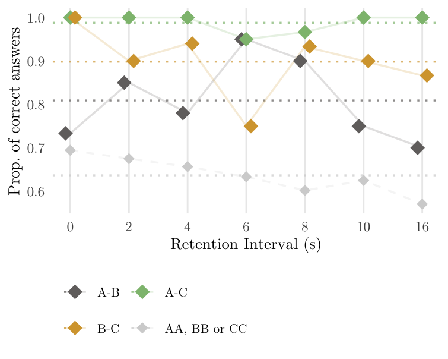

```r
plot2 <- timePerformanceSameCommunities %>%
  ggplot(aes(x=deltaT, y=propCorrect))+
  geom_hline(
    data = pooled_avg_propCorrect,
    aes(yintercept = y, color = community),
    alpha = 0.7,
    linetype = "dotted",
    linewidth = 0.6
  )+
  geom_line(
    data = timePerformanceSameCommunities,
    aes(x = deltaT, y = propCorrect, group = 1, color = "AA, BB or CC"),
    linewidth = 0.6,
    alpha = 0.2,
    linetype = 2
  ) +
  geom_line(
    data = meanValuesDifferentCommunitiesAB,
    aes(x = deltaT, y = propCorrect, group = 1, color = "A-B"),
    linewidth = 0.6,
    alpha = 0.2
  ) +
  geom_line(
    data = meanValuesDifferentCommunitiesAC,
    aes(x = deltaT, y = propCorrect, group = 1, color = "A-C"),
    linewidth = 0.6,
    alpha = 0.2
  ) +
  geom_line(
    data = meanValuesDifferentCommunitiesBC,
    aes(x = deltaT, y = propCorrect, group = 1, color = "B-C"),
    linewidth = 0.6,
    alpha = 0.2
  ) +
  geom_point(data = timePerformanceSameCommunities, aes(x=deltaT, y=propCorrect, color = "AA, BB or CC"),shape = 18, size = 3 , position = position_nudge(x = 0)) +
  geom_point(data = meanValuesDifferentCommunitiesAB, aes(x=deltaT, y=propCorrect, color = "A-B"),shape = 18, size = 4, position = position_nudge(x = -0.08)) +
  geom_point(data = meanValuesDifferentCommunitiesAC, aes(x=deltaT, y=propCorrect, color = "A-C"),shape = 18, size = 4) +
  geom_point(data = meanValuesDifferentCommunitiesBC, aes(x=deltaT, y=propCorrect, color = "B-C"),shape = 18, size = 4, position = position_nudge(x = 0.08)) +
  xlab("Retention Interval (s)") +
  ylab("Prop. of correct answers") +
  theme_minimal(base_family = paperFont) +
  theme(
        axis.title.x = element_text(size = 10),
        axis.title.y = element_text(size = 10),
        panel.grid.major.y = element_blank(),
        panel.grid.minor.y = element_blank()
  ) +
  scale_color_manual(
    name = "Communities",
    breaks = c("A-B", "A-C", "B-C", "AA, BB or CC"),
    values = c(
      "AA, BB or CC" = "lightgray",
      "A-B" = "#726F6E",
      "A-C" = "#8EBE7E",
      "B-C" = "#D6A43B"
    )
  ) +
  guides(
    color = guide_legend(ncol = 2, byrow = TRUE)
  ) +
  scale_x_discrete(expand = expansion(add = 0.3)) +
  theme(
    legend.position = "bottom",
    legend.justification = "left",
    legend.box.just = "left",
    legend.text  = element_text(size = 8),
    legend.title = element_blank(),
  )

print(plot2)
```

```r
savePaperFig(plot2, "exp2_propCorrectCommunities.pdf", width = 10, height = 8)
```

Proportion of different-speech trials in which participants wrote at least one attribute.

```r
data %>%
  filter(SpeakerCondition == "DS") %>%
  mutate(between = Communities %in% c("A-B", "A-C", "B-C")) %>%
  group_by(between) %>%
  summarise(
    propWithAttributes          = mean(hasAttributes)
  )
```

```
## # A tibble: 2 × 2
##   between propWithAttributes
##   <lgl>                <dbl>
## 1 FALSE                0.412
## 2 TRUE                 0.755
```

## Empirical sensitivity

For each participant, speech condition and retention interval, the sensitivity $d'$ and the criterion $c$ are computed from the hit rate (HR) and the false alarm rate (FAR) of the within-community trials:

$$d' = \Phi^{-1}(\mathrm{HR}) -
\Phi^{-1}(\mathrm{FAR}), \qquad
c = -\frac{\Phi^{-1}(\mathrm{HR}) +
\Phi^{-1}(\mathrm{FAR})}{2}.$$

Rates of 0 and 1 are corrected to $1/(2M)$ and $1 - 1/(2M)$, with $M$ the number of trials of the rate.

```r
dataSameCommunitiesSS <- data %>%
  filter(!Communities %in% c("A-B", "B-C", "A-C")) %>%
  filter(SpeakerCondition == "SS")

timePerformanceSameCommunitiesSS <- dataSameCommunitiesSS %>%
  group_by(ParticipantID, deltaT, type) %>%
  summarise(count = n(), .groups = "drop") %>%
  pivot_wider(names_from = type, values_from = count, values_fill = 0) %>%
  mutate(
    hr = hit / (hit + miss),
    hr = ifelse(hr == 0, 1/(2*(hit+miss)), hr),
    hr = ifelse(hr == 1, 1-1/(2*(hit+miss)), hr),
    far = fa/(fa+cr),
    far = ifelse(far == 0, 1/(2*(fa+cr)), far),
    far = ifelse(far == 1, 1-1/(2*(fa+cr)), far),
    zhr = qnorm(hr),
    zfar = qnorm(far),
    dprime = zhr-zfar,
    crit = -(zhr + zfar) / 2,
  ) %>%
  group_by(deltaT) %>%
  mutate(N = n()) %>%
  ungroup() %>%
  mutate(deltaT = factor(deltaT))

dataSameCommunitiesDS <- data %>%
  filter(!Communities %in% c("A-B", "B-C", "A-C")) %>%
  filter(SpeakerCondition == "DS")

timePerformanceSameCommunitiesDS <- dataSameCommunitiesDS %>%
  group_by(ParticipantID, deltaT, type) %>%
  summarise(count = n(), .groups = "drop") %>%
  pivot_wider(names_from = type, values_from = count, values_fill = 0) %>%
  mutate(
    hr = hit / (hit + miss),
    hr = ifelse(hr == 0, 1/(2*(hit+miss)), hr),
    hr = ifelse(hr == 1, 1-1/(2*(hit+miss)), hr),
    far = fa/(fa+cr),
    far = ifelse(far == 0, 1/(2*(fa+cr)), far),
    far = ifelse(far == 1, 1-1/(2*(fa+cr)), far),
    zhr = qnorm(hr),
    zfar = qnorm(far),
    dprime = zhr-zfar,
    crit = -(zhr + zfar) / 2,
  ) %>%
  group_by(deltaT) %>%
  mutate(N = n()) %>%
  ungroup() %>%
  mutate(deltaT = factor(deltaT))
```

Mean and SD of $d'$ per retention interval.

```r
dprimeSummarySS <- timePerformanceSameCommunitiesSS %>%
  group_by(deltaT) %>%
  summarise(
    dprime.mean = mean(dprime, na.rm = TRUE),
    dprime.sd   = sd(dprime, na.rm = TRUE),
    N           = n()
  )

dprimeSummaryDS <- timePerformanceSameCommunitiesDS %>%
  group_by(deltaT) %>%
  summarise(
    dprime.mean = mean(dprime, na.rm = TRUE),
    dprime.sd   = sd(dprime, na.rm = TRUE),
    N           = n()
  )

dprimeSummarySS
```

```
## # A tibble: 7 × 4
##   deltaT dprime.mean dprime.sd     N
##   <fct>        <dbl>     <dbl> <int>
## 1 0             2.18     0.636    30
## 2 2             1.82     0.702    20
## 3 4             1.74     0.731    50
## 4 6             1.79     0.708    20
## 5 8             1.52     0.802    30
## 6 10            1.63     0.741    20
## 7 16            1.35     0.630    30
```

```r
dprimeSummaryDS
```

```
## # A tibble: 7 × 4
##   deltaT dprime.mean dprime.sd     N
##   <fct>        <dbl>     <dbl> <int>
## 1 0            1.19      0.735    30
## 2 2            1.06      0.832    20
## 3 4            0.931     0.757    50
## 4 6            0.756     0.634    20
## 5 8            0.603     0.719    30
## 6 10           0.713     0.902    20
## 7 16           0.388     0.547    30
```

Distribution of the participants’ $d'$ per retention interval, with the same-speech condition on the right and the different-speech condition on the left of each retention interval.

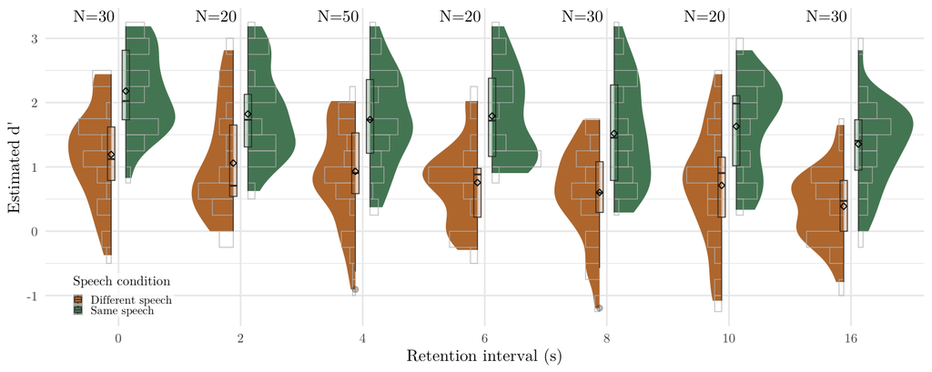

```r
dprimeFig <- ggplot() +
  # SS
  geom_violinhist(
    data = timePerformanceSameCommunitiesSS,
    mapping = aes(x = deltaT, y = dprime, fill = "Same speech"),
    scale = "area", nudge_value = 0.06, binwidth = 0.25,
    hist_color = "grey", hist_alpha = 0, hist_side_flip = TRUE, hist_linewidth = 0.2
  ) +
  geom_boxplot(
    data = timePerformanceSameCommunitiesSS,
    mapping = aes(x = deltaT, y = dprime, fill = "Same speech"),
    linewidth = 0.25, width = 0.06, alpha = 0.3,
    position = position_nudge(x = 0.06)
  ) +
  stat_summary(
    data = timePerformanceSameCommunitiesSS,
    mapping = aes(x = deltaT, y = dprime),
    geom = "point", fun = "mean", size = 1, shape = 5,
    position = position_nudge(x = 0.06)
  ) +
  # DS
  geom_violinhist(
    data = timePerformanceSameCommunitiesDS,
    mapping = aes(x = deltaT, y = dprime, fill = "Different speech"),
    side = "left", scale = "area", nudge_value = 0.06, binwidth = 0.25,
    hist_color = "grey", hist_alpha = 0, hist_side_flip = TRUE, hist_linewidth = 0.2
  ) +
  geom_boxplot(
    data = timePerformanceSameCommunitiesDS,
    mapping = aes(x = deltaT, y = dprime, fill = "Different speech"),
    linewidth = 0.25, width = 0.06, alpha = 0.3,
    position = position_nudge(x = -0.06)
  ) +
  stat_summary(
    data = timePerformanceSameCommunitiesDS,
    mapping = aes(x = deltaT, y = dprime),
    geom = "point", fun = "mean", size = 1, shape = 5,
    position = position_nudge(x = -0.06)
  ) +
  # Number of participants per retention interval
  geom_text(
    data = distinct(timePerformanceSameCommunitiesSS, deltaT, N),
    aes(x = deltaT, label = paste0("N=", N), y = Inf),
    position = position_nudge(x = -0.2),
    vjust = 1.2, size = 3.5, family = paperFont
  ) +
  scale_fill_manual(name = "Speech condition", values = speechColours) +
  guides(fill = guide_legend(override.aes = list(alpha = 0.6))) +
  labs(x = "Retention interval (s)", y = "Estimated d'") +
  theme_paper() +
  theme(
    legend.position        = "inside",
    legend.position.inside = c(0.03, 0.03),
    legend.justification   = c("left", "bottom"),
    legend.title           = element_text(size = 8),
    legend.text            = element_text(size = 7),
    legend.key.size        = unit(0.4, "lines"),
    legend.spacing.y       = unit(0.1, "lines"),
    legend.background      = element_rect(fill = scales::alpha("white", 0.7), colour = NA),
    legend.margin          = margin(1, 1, 1, 1)
  )

dprimeFig
```

```r
savePaperFig(dprimeFig, "exp2_dprimeTimeSplit.pdf", width = 20, height = 8)
```

# Bayesian signal detection model

Each trial $i$, with participant $j$ and speech condition $k$, is modeled as a signal detection judgement. $r_i = 1$ if the participant answered “same room”, and $X_i = 1$ if both rooms were the same. The criterion $c_j$ sets the false alarm rate, and the familiarity $d'_{jk}$ elicited by the first room decays with the retention interval $\Delta t$ following the power-law function $\delta$, with $\delta = 1$ at $\Delta t = 0$.

$$\begin{aligned}
r_i &\sim \operatorname{Bernoulli}(p_i) \\[1ex]
p_i &= \Phi(-c_j + d'_{jk} X_i \delta_k(\Delta t)) \\
\delta_k(\Delta t)&= \frac{a_k}{a_k + (\Delta t)^{b_k}} \\[3ex]
&\text{Participant level} \\[1ex]
c_j &\sim \mathcal{N}(\beta^{\text{crit}}, \sigma^{\text{crit}}) \\
d'_{jk} &\sim \mathcal{N}(\beta^{\text{fam}}_k,
\sigma^{\text{fam}}) \\[3ex]
&\text{Population level, parameter priors} \\[1ex]
\beta^{\text{fam}}_{k=\mathrm{SS}} &\sim \mathcal{N}(4,1), \\
\beta^{\text{fam}}_{k=\mathrm{DS}} &\sim \mathcal{N}(2,1), \\
\sigma^{\text{fam}} &\sim
\operatorname{Log\text{-}Normal}(-0.5,0.2), \\[1ex]
\beta^{\text{crit}} &\sim \mathcal{N}(1,1), \\
\sigma^{\text{crit}} &\sim
\operatorname{Log\text{-}Normal}(-0.5,0.2), \\[1ex]
a_k &\sim \operatorname{Log\text{-}Normal}(2, 1), \\
b_k &\sim \operatorname{Half\text{-}Normal}(0,1).
\end{aligned}$$

The model is implemented in `stan/room-acoustic-memory.stan`. In the Stan model and in the parameter names below, the speech condition index is $k = 1$ for different speech (DS) and $k = 2$ for same speech (SS).

The model is fitted to the within-community trials only.

```r
dataSameCommunities <- data %>%
  filter(!Communities %in% c("A-B", "B-C", "A-C"))

n_participants <- length(unique(dataSameCommunities$ParticipantID))
N = nrow(dataSameCommunities)

# Prepare the data list
stan_data <- list(N = nrow(dataSameCommunities),
                  X = dataSameCommunities$isSame ,
                  R = dataSameCommunities$saySame,
                  K_speech = 2,
                  k_speech = (dataSameCommunities$sameSpeaker+1),
                  deltaT = dataSameCommunities$deltaT,
                  J_participants = n_participants,
                  pid = dataSameCommunities$ParticipantID,
                  prior_only = 0)

stanFile <- file.path(stanDir, "room-acoustic-memory.stan")
```

## Prior predictive check

Sample the same model with `prior_only = 1`: the responses are ignored and the draws come from the priors only. Each draw of `y_rep` is a full simulated experiment.

```r
fitPriorFile <- "room-acoustic-memory_prior.rds"

if (refit || !file.exists(fitPriorFile)) {
  fit_prior <- stan(
    file = stanFile,
    data = modifyList(stan_data, list(prior_only = 1)),
    iter = 1000,
    chains = 4,
    seed = 123,
    save_warmup = FALSE)
  saveRDS(fit_prior, fitPriorFile)
} else {
  fit_prior <- readRDS(fitPriorFile)
}
```

Prior draws of the population parameters.

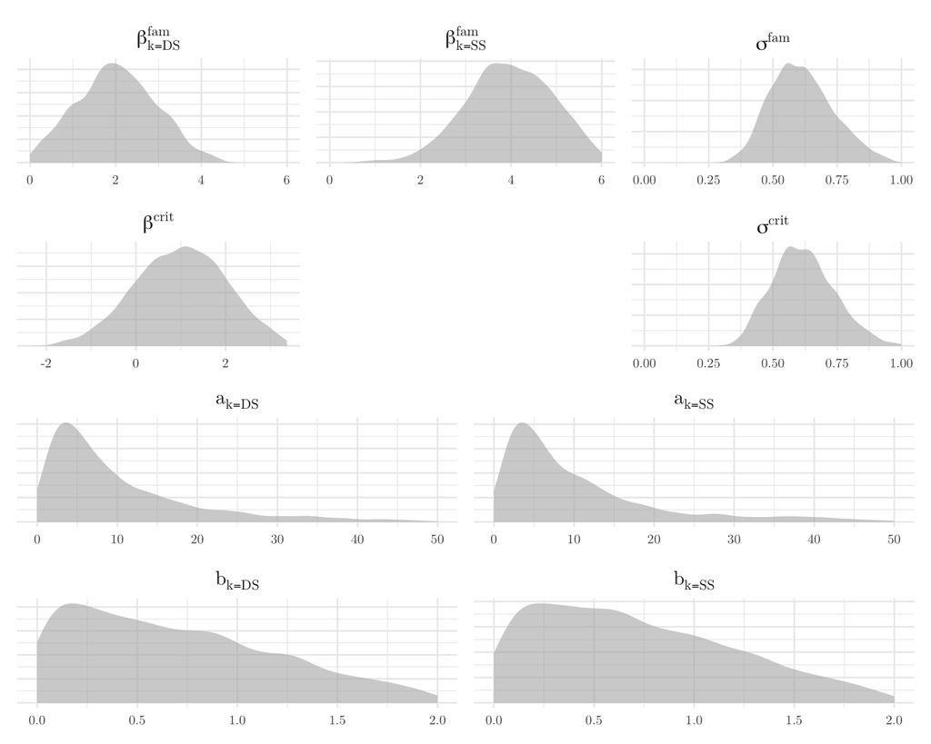

```r
popPars <- c("beta_fam[1]", "beta_fam[2]", "sigma_fam",
             "beta_crit", "sigma_crit",
             "a_decay[1]", "a_decay[2]", "b_decay[1]", "b_decay[2]")

# Panel titles as plotmath expressions
parLabels <- as_labeller(c(
  "beta_fam[1]" = 'beta[k=="DS"]^fam',
  "beta_fam[2]" = 'beta[k=="SS"]^fam',
  "sigma_fam"   = "sigma^fam",
  "beta_crit"   = "beta^crit",
  "sigma_crit"  = "sigma^crit",
  "a_decay[1]"  = 'a[k=="DS"]',
  "a_decay[2]"  = 'a[k=="SS"]',
  "b_decay[1]"  = 'b[k=="DS"]',
  "b_decay[2]"  = 'b[k=="SS"]'
), default = label_parsed)

# Common x range for the parameters
xLims <- tibble(
  parameter = factor(c("beta_fam[1]", "beta_fam[2]", "sigma_fam", "sigma_crit",
                       "a_decay[1]", "a_decay[2]", "b_decay[1]", "b_decay[2]"),
                     levels = popPars),
  lo = 0,
  hi = c(6, 6, 1, 1, 50, 50, 2, 2))
xLimsLong <- pivot_longer(xLims, c(lo, hi), values_to = "value")

# One panel per parameter
plotLayout <- "
AABBCC
DD##EE
FFFGGG
HHHIII
"

priorParsPlotData <- as.data.frame(as.matrix(fit_prior, pars = popPars)) %>%
  pivot_longer(everything(), names_to = "parameter", values_to = "value") %>%
  mutate(parameter = factor(parameter, levels = popPars)) %>%
  left_join(xLims, by = "parameter") %>%
  group_by(parameter) %>%
  filter(value <= quantile(value, 0.99), is.na(hi) | between(value, lo, hi)) %>%
  ungroup()

priorParsPlot <- wrap_plots(lapply(popPars, function(par) {
  ggplot(filter(priorParsPlotData, parameter == par), aes(x = value)) +
    geom_density(fill = "grey70", alpha = 0.6, colour = NA) +
    geom_blank(data = filter(xLimsLong, parameter == par),
               aes(x = value), inherit.aes = FALSE) +
    facet_wrap(~ parameter, labeller = parLabels) +
    labs(x = NULL, y = NULL) +
    theme_minimal(base_family = paperFont, base_size = 10) +
    theme(axis.text.y = element_blank(), strip.text = element_text(size = 12))
}), design = plotLayout)

print(priorParsPlot)
```

```r
savePaperFig(priorParsPlot, "exp2_priorParsPlot.pdf", width = 20, height = 16)
```

Each simulated experiment is summarised as P(say “same”) per condition, trial type and retention interval, and compared with the observed data.

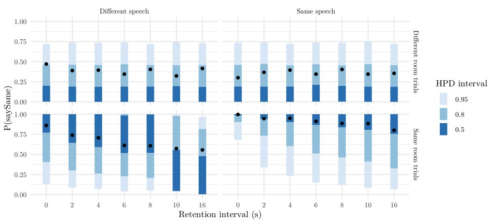

```r
y_prior <- rstan::extract(fit_prior, pars = "y_rep")$y_rep   # draws x trials

priorPred <- as_tibble(t(y_prior[sample(nrow(y_prior), 2000), ]),
                       .name_repair = ~ paste0("draw", seq_along(.x))) %>%
  bind_cols(dataSameCommunities %>% select(sameSpeaker, isSame, deltaT)) %>%
  pivot_longer(starts_with("draw"), names_to = "draw", values_to = "saySame") %>%
  group_by(draw, sameSpeaker, isSame, deltaT) %>%
  summarise(pSame = mean(saySame), .groups = "drop")

observed <- dataSameCommunities %>%
  group_by(sameSpeaker, isSame, deltaT) %>%
  summarise(pSame = mean(saySame), .groups = "drop")

priorPredPlot <- ggplot(priorPred, aes(x = factor(deltaT), y = pSame)) +
  stat_interval(.width = c(0.5, 0.8, 0.95), point_interval = "median_hdci") +  # prior predictive
  geom_point(data = observed, colour = "black") +           # observed data
  facet_grid(isSame ~ sameSpeaker,
             labeller = labeller(isSame = c(`0` = "Different room trials", `1` = "Same room trials"),
                                 sameSpeaker = c(`0` = "Different speech", `1` = "Same speech"))) +
  scale_color_brewer() +
  labs(x = "Retention interval (s)", y = "P(saySame)", colour = "HPD interval") +
  theme_minimal(base_family = paperFont, base_size = 10)

print(priorPredPlot)
```

```r
savePaperFig(priorPredPlot, "exp2_priorPredPlot.pdf", width = 20, height = 9)
```

### Prior decay function

The decay parameters $a$ and $b$ have the same prior in both conditions, so the prior decay function is identical for DS and SS. The draws of both conditions are pooled into a single curve.

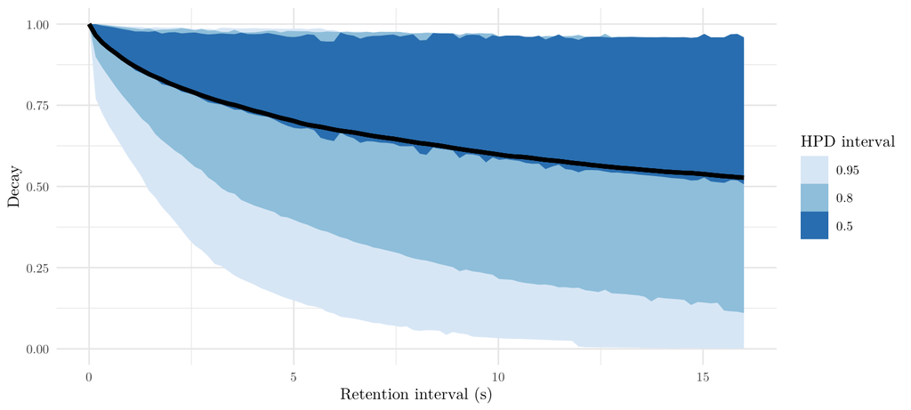

```r
priorDecay <- as.data.frame(as.matrix(fit_prior, pars = c("a_decay", "b_decay"))) %>%
  slice_sample(n = 4000) %>%
  mutate(draw = row_number()) %>%
  pivot_longer(-draw,
               names_to = c(".value", "k"),
               names_pattern = "(.)_decay\\[(\\d)\\]") %>%
  crossing(deltaT = seq(0, 16, length.out = 100)) %>%
  mutate(decay = a / (a + deltaT^b))

priorDecayPlot <- ggplot(priorDecay, aes(x = deltaT, y = decay)) +
  stat_lineribbon(.width = c(0.5, 0.8, 0.95), point_interval = "median_hdci") +
  scale_fill_brewer() +
  coord_cartesian(ylim = c(0, 1)) +
  labs(x = "Retention interval (s)", y = "Decay", fill = "HPD interval") +
  theme_minimal(base_family = paperFont, base_size = 10)

print(priorDecayPlot)
```

```r
savePaperFig(priorDecayPlot, "exp2_priorDecayPlot.pdf", width = 20, height = 9)
```

## Fitting the model

```r
fitFile <- "room-acoustic-memory_fit.rds"

if (refit || !file.exists(fitFile)) {
  fit <- stan(
    file = stanFile,
    data = stan_data,
    iter = 4000,
    chains = 4,
    seed = 123,
    save_warmup = FALSE,
    pars = "y_rep", include = FALSE)
  saveRDS(fit, fitFile)
} else {
  fit <- readRDS(fitFile)
}
```

### Convergence diagnostics

$\hat{R}$ and effective sample size of all parameters, and the trace plots of the population-level parameters.

```r
rhatESS <- data.frame(summary(fit)$summary[, c("Rhat", "n_eff")])

c(maxRhat = max(rhatESS$Rhat, na.rm = TRUE),
  minESS  = min(rhatESS$n_eff, na.rm = TRUE))
```

```
##     maxRhat      minESS
##    1.001915 1554.530013
```

```r
mcmc_trace(
  rstan::extract(fit, permuted = FALSE, inc_warmup = FALSE),
   pars = c("beta_crit", "sigma_crit", "a_decay[1]", "b_decay[1]", "a_decay[2]", "b_decay[2]", "beta_fam[1]", "beta_fam[2]", "sigma_fam")
)
```

[figure not shown]

## Posterior predictive check

`gqs()` reruns only the `generated quantities` block of the model on a subset of the posterior draws, giving simulated experiments from the fitted model.

```r
model <- stan_model(stanFile)

draws <- as.matrix(fit, pars = c("beta_crit", "sigma_crit", "beta_fam", "sigma_fam",
                                     "z_crit", "z_fam", "a_decay", "b_decay"))
draws <- draws[sample(nrow(draws), 2000), ]

gq     <- gqs(model, data = stan_data, draws = draws, seed = 123)
```

```
##
##  Elapsed Time: 0.573 seconds (Generated Quantities)
```

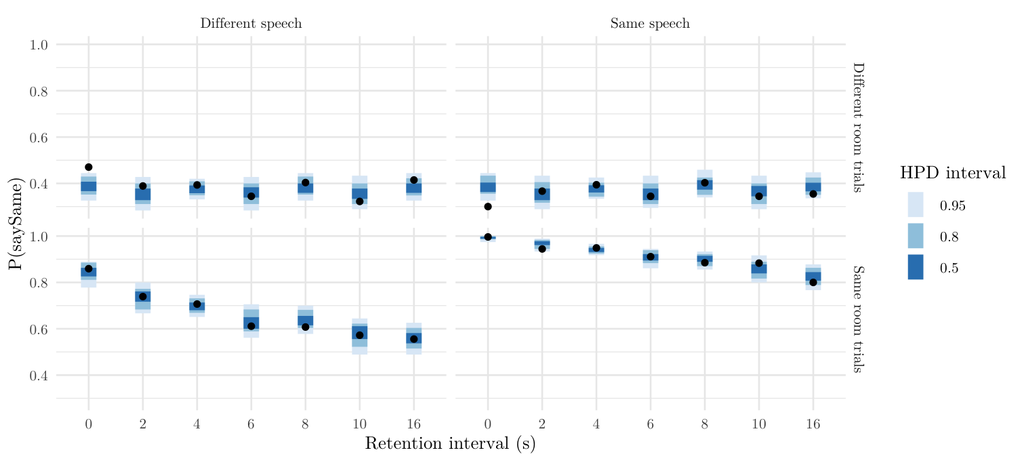

```r
y_post <- rstan::extract(gq, pars = "y_rep")$y_rep    # draws x trials

postPred <- as_tibble(t(y_post),
                      .name_repair = ~ paste0("draw", seq_along(.x))) %>%
  bind_cols(dataSameCommunities %>% select(sameSpeaker, isSame, deltaT)) %>%
  pivot_longer(starts_with("draw"), names_to = "draw", values_to = "saySame") %>%
  group_by(draw, sameSpeaker, isSame, deltaT) %>%
  summarise(pSame = mean(saySame), .groups = "drop")

postPredPlot <- ggplot(postPred, aes(x = factor(deltaT), y = pSame)) +
  stat_interval(.width = c(0.5, 0.8, 0.95), point_interval = "median_hdci") +  # posterior predictive
  geom_point(data = observed, colour = "black") +           # observed data
  facet_grid(isSame ~ sameSpeaker,
             labeller = labeller(isSame = c(`0` = "Different room trials", `1` = "Same room trials"),
                                 sameSpeaker = c(`0` = "Different speech", `1` = "Same speech"))) +
  scale_color_brewer() +
  labs(x = "Retention interval (s)", y = "P(saySame)", colour = "HPD interval") +
  theme_minimal(base_family = paperFont, base_size = 10)

print(postPredPlot)
```

```r
savePaperFig(postPredPlot, "exp2_posteriorPredPlot.pdf", width = 20, height = 9)
```

## Prior to posterior comparison

How much the data updated each population parameter: prior and posterior distributions overlaid.

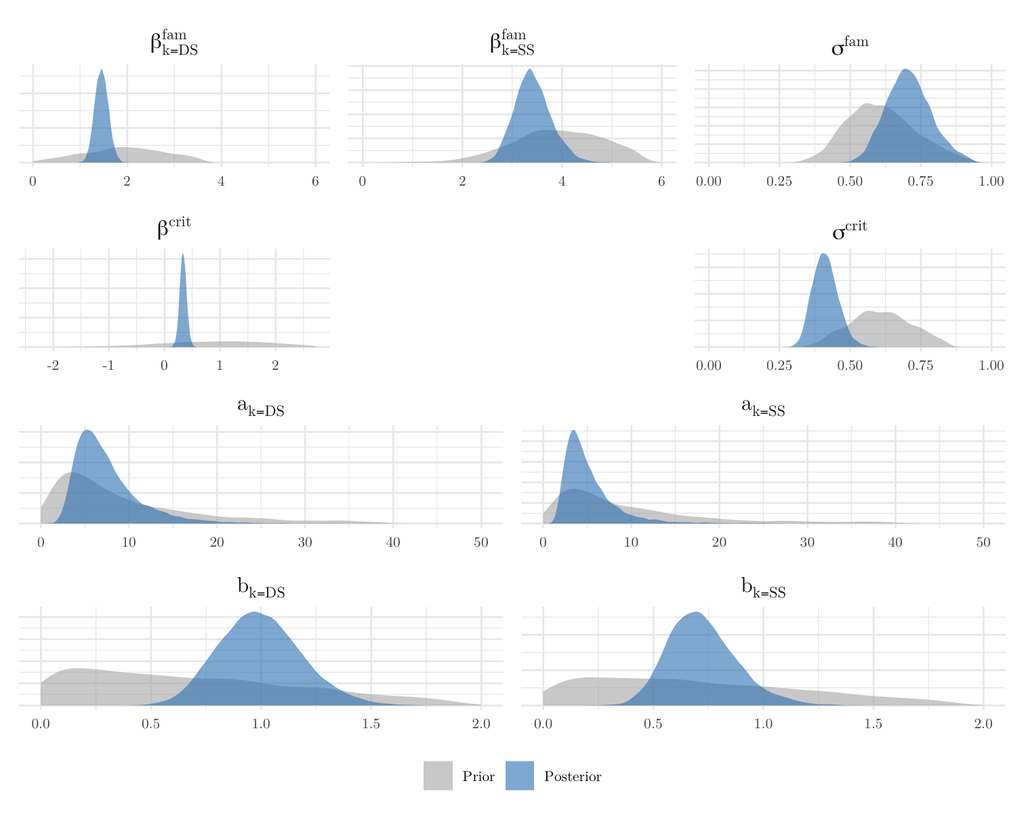

```r
# popPars, xLims, xLimsLong and plotLayout are defined in the prior
# predictive check
priorPost <- bind_rows(
  Prior     = as.data.frame(as.matrix(fit_prior, pars = popPars)),
  Posterior = as.data.frame(as.matrix(fit,   pars = popPars)),
  .id = "stage"
) %>%
  pivot_longer(-stage, names_to = "parameter", values_to = "value") %>%
  mutate(parameter = factor(parameter, levels = popPars),
         stage     = factor(stage, levels = c("Prior", "Posterior")))


priorPostPlotData <- priorPost %>%
  left_join(xLims, by = "parameter") %>%
  group_by(parameter) %>%
  filter(value <= quantile(value, 0.99), is.na(hi) | between(value, lo, hi)) %>%
  ungroup()

priorPostPlot <- wrap_plots(lapply(popPars, function(par) {
  ggplot(filter(priorPostPlotData, parameter == par), aes(x = value, fill = stage)) +
    geom_density(alpha = 0.6, colour = NA) +
    geom_blank(data = filter(xLimsLong, parameter == par),
               aes(x = value), inherit.aes = FALSE) +
    facet_wrap(~ parameter, labeller = parLabels) +
    scale_fill_manual(values = c(Prior = "grey70", Posterior = "#3182bd")) +
    labs(x = NULL, y = NULL, fill = NULL) +
    theme_minimal(base_family = paperFont, base_size = 10) +
    theme(axis.text.y = element_blank(), strip.text = element_text(size = 12))
}), design = plotLayout, guides = "collect") &
  theme(legend.position = "bottom")

print(priorPostPlot)
```

```r
savePaperFig(priorPostPlot, "exp2_priorPostPlot.pdf", width = 20, height = 16)
```

# Posterior results

Posterior draws of the population-level parameters, and quantities derived from them.

```r
posterior <- as.matrix(fit, pars = c("beta_crit", "sigma_crit", "a_decay[1]", "b_decay[1]", "a_decay[2]", "b_decay[2]", "beta_fam[1]", "beta_fam[2]", "sigma_fam"))

# Posterior transformations

posterior <- cbind(posterior, "loga_decay[1]" = log(posterior[, "a_decay[1]"]))
posterior <- cbind(posterior, "loga_decay[2]" = log(posterior[, "a_decay[2]"]))

posterior <- cbind(posterior, "beta_fam_diff" = posterior[, "beta_fam[2]"] - posterior[, "beta_fam[1]"])
posterior <- cbind(posterior, "a_diff" = posterior[, "a_decay[2]"] - posterior[, "a_decay[1]"])
posterior <- cbind(posterior, "b_diff" = posterior[, "b_decay[2]"] - posterior[, "b_decay[1]"])

posterior <- cbind(posterior, "loga_diff" = posterior[, "loga_decay[2]"] - posterior[, "loga_decay[1]"])
```

## Parameter estimates

Posterior mean and 95% and 80% highest posterior density intervals (HPDI) of the parameters and derived quantities.

```r
pars <- c("beta_crit",
          "sigma_crit",
          "loga_decay[1]",
          "a_decay[1]",
          "b_decay[1]",
          "loga_decay[2]",
          "a_decay[2]",
          "b_decay[2]",
          "beta_fam[1]",
          "beta_fam[2]",
          "sigma_fam",
          "beta_fam_diff",
          "a_diff",
          "loga_diff",
          "b_diff")

summ_tbl <- lapply(pars, function(p) {
  x <- as.numeric(posterior[, p])
  # Drop non-finite if needed
  x <- x[is.finite(x)]
  hd95 <- bayestestR::hdi(x, ci = 0.95)  # returns data.frame with CI_low, CI_high
  hd80 <- bayestestR::hdi(x, ci = 0.80)
  data.frame(
    parameter = p,
    mean      = mean(x),
    hpdi95_low  = hd95$CI_low,
    hpdi95_high = hd95$CI_high,
    hpdi80_low  = hd80$CI_low,
    hpdi80_high = hd80$CI_high
  )
}) %>% bind_rows()

knitr::kable(summ_tbl, digits = 3)
```

| parameter | mean | hpdi95_low | hpdi95_high | hpdi80_low | hpdi80_high |
| --- | --- | --- | --- | --- | --- |
| beta_crit | 0.336 | 0.212 | 0.457 | 0.258 | 0.415 |
| sigma_crit | 0.413 | 0.326 | 0.497 | 0.355 | 0.469 |
| loga_decay[1] | 1.914 | 1.053 | 2.796 | 1.274 | 2.417 |
| a_decay[1] | 7.537 | 2.327 | 15.191 | 2.981 | 10.229 |
| b_decay[1] | 0.996 | 0.640 | 1.370 | 0.751 | 1.228 |
| loga_decay[2] | 1.526 | 0.643 | 2.573 | 0.841 | 2.083 |
| a_decay[2] | 5.289 | 1.481 | 11.464 | 1.855 | 7.077 |
| b_decay[2] | 0.724 | 0.420 | 1.035 | 0.507 | 0.894 |
| beta_fam[1] | 1.456 | 1.195 | 1.757 | 1.267 | 1.631 |
| beta_fam[2] | 3.417 | 2.745 | 4.159 | 2.943 | 3.866 |
| sigma_fam | 0.710 | 0.553 | 0.875 | 0.602 | 0.808 |
| beta_fam_diff | 1.961 | 1.224 | 2.711 | 1.408 | 2.370 |
| a_diff | -2.248 | -13.705 | 6.696 | -7.295 | 3.154 |
| loga_diff | -0.388 | -1.677 | 0.895 | -1.242 | 0.398 |
| b_diff | -0.273 | -0.752 | 0.196 | -0.574 | 0.039 |

Posterior densities of the main model parameters, with the mean and the 80% (thick) and 95% (thin) HPDIs.

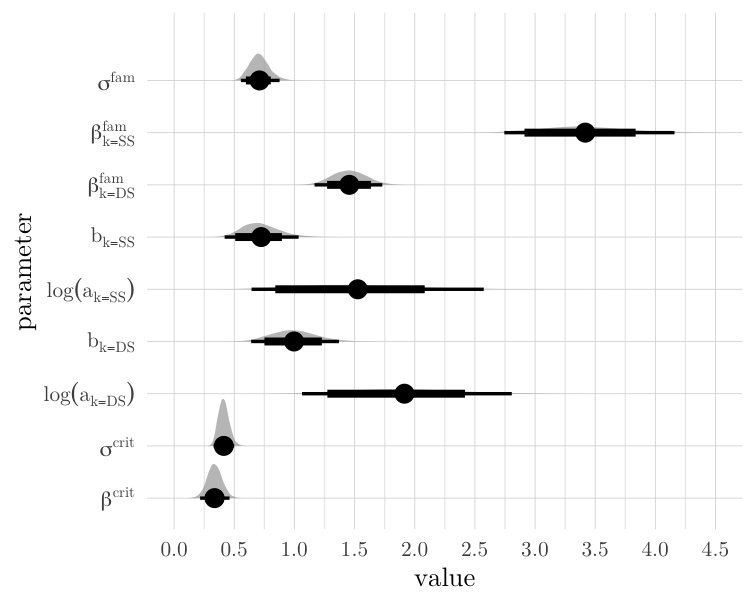

```r
pars <- c(
  "beta_crit",
  "sigma_crit",
  "loga_decay[1]",
  "b_decay[1]",
  "loga_decay[2]",
  "b_decay[2]",
  "beta_fam[1]",
  "beta_fam[2]",
  "sigma_fam"
)

# Convert to a tidy draws data frame, then pivot long for tidybayes
draws_df <- posterior::as_draws_df(posterior) %>%
  select(all_of(pars)) %>%
  pivot_longer(
    everything(),
    names_to = "parameter",
    values_to = "value"
  ) %>%
  mutate(
    parameter = factor(
      parameter,
      levels = pars
    )
  )
rowLims <- c(1, length(pars) + 0.7)

plotHalfeye <- ggplot(draws_df, aes(x = value, y = parameter)) +
  stat_halfeye(
    .width = c(0.8, 0.95),
    point_interval = "mean_hdi",
    slab_alpha = 0.7,
    normalize = "panels"
  ) +
  scale_y_discrete(labels = c(
    "beta_fam[1]"   = expression(beta[k=="DS"]^fam),
    "beta_fam[2]"   = expression(beta[k=="SS"]^fam),
    "sigma_fam"     = expression(sigma^fam),
    "loga_decay[1]" = expression(log(a[k=="DS"])),
    "loga_decay[2]" = expression(log(a[k=="SS"])),
    "b_decay[1]"    = expression(b[k=="DS"]),
    "b_decay[2]"    = expression(b[k=="SS"]),
    "beta_crit"     = expression(beta^crit),
    "sigma_crit"    = expression(sigma^crit)
  )) +
  scale_x_continuous(breaks = seq(0, 4.5, by = 0.5)) +
  coord_cartesian(xlim = c(0, 4.5), ylim = rowLims) +
  theme_minimal(base_family = paperFont, base_size = 10) +
  theme(
    panel.grid.major.x = element_line(linewidth = 0.15, colour = "grey85"),
    panel.grid.major.y = element_line(linewidth = 0.15, colour = "grey85")
  )

print(plotHalfeye)
```

```r
savePaperFig(plotHalfeye, "exp2_parameterEstimatesRaw.pdf", width = 10, height = 8)
```

The same figure with the values of the table on the side (paper figure).

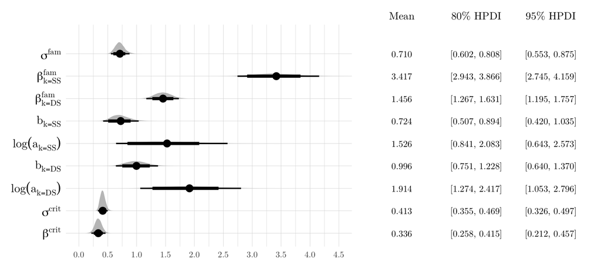

```r
estimateValues <- summ_tbl %>%
  filter(parameter %in% pars) %>%
  transmute(
    parameter = factor(parameter, levels = pars),
    Mean = sprintf("%.3f", mean),
    `80% HPDI` = sprintf("[%.3f, %.3f]", hpdi80_low, hpdi80_high),
    `95% HPDI` = sprintf("[%.3f, %.3f]", hpdi95_low, hpdi95_high)
  ) %>%
  pivot_longer(-parameter, names_to = "column", values_to = "label") %>%
  mutate(column = factor(column, levels = c("Mean", "80% HPDI", "95% HPDI")))

estimateTable <- ggplot(estimateValues, aes(x = column, y = parameter, label = label)) +
  geom_text(family = paperFont, size = 3) +
  scale_x_discrete(position = "top") +
  coord_cartesian(ylim = rowLims) +
  labs(x = NULL, y = NULL) +
  theme_void(base_family = paperFont, base_size = 10) +
  theme(axis.text.x.top = element_text(margin = margin(b = 4)))

estimatesFig <- plotHalfeye + labs(x = NULL, y = NULL) +
  theme(axis.text.y = element_text(colour = "black", size = 11)) +
  estimateTable +
  plot_layout(widths = c(1.2, 1))

print(estimatesFig)
```

```r
savePaperFig(estimatesFig, "exp2_parameterEstimatesTable.pdf", width = 20, height = 9)
```

## Contrasts between speech conditions

Posterior contrasts SS - DS of $\beta^{\text{fam}}$, $\log(a)$ and $b$, with the mean and the 80% and 95% HPDIs.

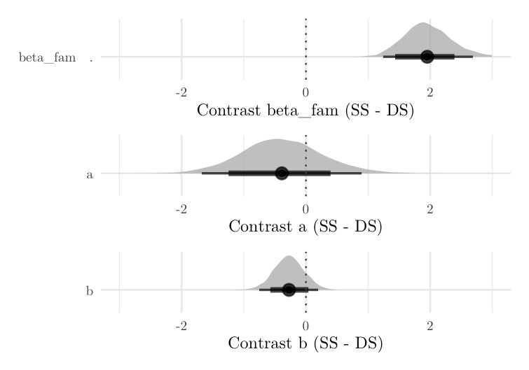

```r
d_beta <- posterior %>%
  spread_draws(beta_fam_diff) %>%
  transmute(parameter = "beta_fam   .", value = beta_fam_diff)

xlim_beta <- 3

p_beta <- ggplot(d_beta, aes(x = value, y = parameter, fill = parameter)) +
  tidybayes::stat_halfeye(
    .width = c(0.8, 0.95),
    point_interval = "mean_hdi",
    alpha = 0.7,
    fill = "grey70"
  ) +
  geom_vline(xintercept = 0, linetype = "dotted", color = "grey30") +
  scale_x_continuous(limits = c(-xlim_beta, xlim_beta)) +
  labs(x = "Contrast beta_fam (SS - DS)", y = NULL) +
  theme_minimal(base_family = paperFont, base_size = 9)+
  theme(legend.position = "none")

# Plot 2: a_diff
d_a <- posterior %>%
  spread_draws(loga_diff) %>%
  transmute(parameter = "a", value = loga_diff)

xlim_a <- 3

p_a <- ggplot(d_a, aes(x = value, y = parameter, fill = parameter)) +
  tidybayes::stat_halfeye(
    .width = c(0.8, 0.95),
    point_interval = "mean_hdi",
    alpha = 0.7,
    fill = "grey70"
  ) +
  geom_vline(xintercept = 0, linetype = "dotted", color = "grey30") +
  scale_x_continuous(limits = c(-xlim_a, xlim_a)) +
  labs(x = "Contrast a (SS - DS)", y = NULL) +
  theme_minimal(base_family = paperFont, base_size = 9)+
  theme(legend.position = "none")

# Plot 3: b_diff
d_b <- posterior %>%
  spread_draws(b_diff) %>%
  transmute(parameter = "b", value = b_diff)

xlim_b <- xlim_a

p_b <- ggplot(d_b, aes(x = value, y = parameter, fill = parameter)) +
  tidybayes::stat_halfeye(
    .width = c(0.8, 0.95),
    point_interval = "mean_hdi",
    alpha = 0.7,
    fill = "grey70"
  ) +
  geom_vline(xintercept = 0, linetype = "dotted", color = "grey30") +
  scale_x_continuous(limits = c(-xlim_b, xlim_b)) +
  labs(x = "Contrast b (SS - DS)", y = NULL) +
  theme_minimal(base_family = paperFont, base_size = 9)+
  theme(legend.position = "none")

# Stack and save
stacked <- p_beta / p_a / p_b
print(stacked)
```

```r
savePaperFig(stacked, "exp2_contrasts_raw.pdf", width = 10, height = 7)
```

## Decay curves

Decay functions $\delta_k(\Delta t)$ with the posterior mean and the 95% HPDI at each retention interval.

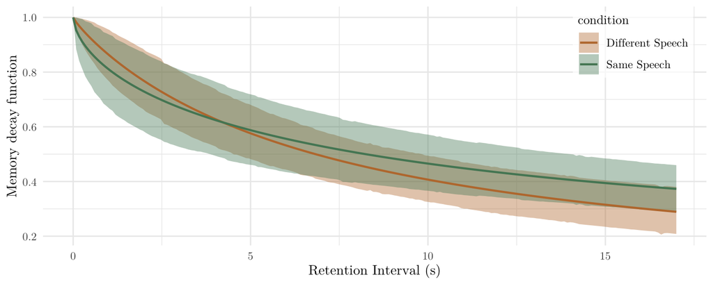

```r
# Extract draws
ps <- as.data.frame(rstan::extract(fit, pars = c("a_decay", "b_decay")))
a1 <- ps$a_decay.1; b1 <- ps$b_decay.1
a2 <- ps$a_decay.2; b2 <- ps$b_decay.2

deltaT <- seq(0, 17, length.out = 200)

# Summaries per x for each condition
summ_one <- function(a, b, condition) {
  out <- lapply(deltaT, function(dt) {
    v <- a / (a + dt^b)
    h95 <- bayestestR::hdi(v, ci = 0.95)
    h80 <- bayestestR::hdi(v, ci = 0.80)
    tibble(
      deltaT = dt,
      median = median(v),
      mean   = mean(v),
      lo80   = h80$CI_low,
      hi80   = h80$CI_high,
      lo95   = h95$CI_low,
      hi95   = h95$CI_high
      )
  }) |> bind_rows()
  out$condition <- condition
  out
}

summ <- bind_rows(
  summ_one(a1, b1, "Different Speech"),
  summ_one(a2, b2, "Same Speech")
)

# Plot: 95% band + mean line
savePlot <- ggplot() +
  # 95% band
  geom_ribbon(data = summ, aes(x = deltaT, ymin = lo95, ymax = hi95, fill = condition),
              alpha = 0.4, color = NA) +
  # Mean line
  geom_line(data = summ, aes(x = deltaT, y = mean, color = condition), linewidth = 0.8) +
  labs(x = "Retention Interval (s)", y = "Memory decay function") +
  scale_color_manual(values = c("Different Speech" = "#BD7A3B", "Same Speech" = "#548665")) +
  scale_fill_manual(values  = c("Different Speech" = "#BD7A3B", "Same Speech" = "#548665")) +
  theme_minimal(base_family = paperFont, base_size = 11)+
  theme(
    legend.position = "inside",
    legend.position.inside = c(0.98, 0.98),   # inside, top-right
    legend.justification = c(1, 1),
    legend.background = element_rect(
      fill = scales::alpha("white", 0.7),     # semi-transparent box
      color = NA
    ),
    legend.key = element_rect(fill = NA, color = NA),
    legend.title = element_text(size = 10),
    legend.text  = element_text(size = 9),
    legend.margin = margin(2, 4, 2, 4)
  )

show(savePlot)
```

```r
savePaperFig(savePlot, "exp2_decayCurves2.pdf", width = 20, height = 8)
```

Decay functions scaled by the population-level familiarity, $\beta^{\text{fam}}_k \times \delta_k(\Delta t)$: the expected population-level familiarity at retention interval $\Delta t$, with the posterior mean and the 95% HPDI.

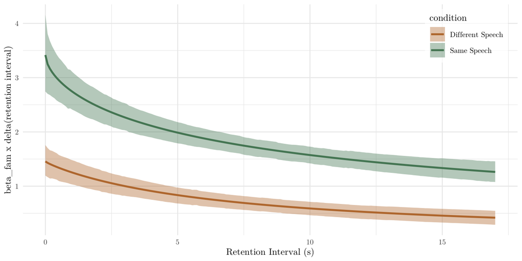

```r
# Extract draws
ps <- as.data.frame(rstan::extract(fit, pars = c("a_decay", "b_decay", "beta_fam", "sigma_fam")))
a1 <- ps$a_decay.1; b1 <- ps$b_decay.1
a2 <- ps$a_decay.2; b2 <- ps$b_decay.2
beta1 <- ps$beta_fam.1
beta2 <- ps$beta_fam.2

deltaT <- seq(0, 17, length.out = 200)

summaryDecays <- function(a, b, beta, condition) {
  out <- lapply(deltaT, function(dt) {
    delta <- a / (a + dt^b)     # per-draw decay
    dprime <- beta * delta      # Decay times beta_fam

    h95 <- bayestestR::hdi(dprime, ci = 0.95)

    tibble(
      deltaT = dt,
      median = median(dprime),
      mean   = mean(dprime),
      lo95   = h95$CI_low,
      hi95   = h95$CI_high
    )
  }) |> bind_rows()
  out$condition <- condition
  out
}

summ <- bind_rows(
  summaryDecays(a1, b1, beta1, "Different Speech"),
  summaryDecays(a2, b2, beta2, "Same Speech")
)

savePlot <- ggplot() +
  geom_ribbon(
    data = summ,
    aes(x = deltaT, ymin = lo95, ymax = hi95, fill = condition),
    alpha = 0.4, color = NA
  ) +
  geom_line(
    data = summ,
    aes(x = deltaT, y = mean, color = condition),
    linewidth = 1
  ) +
  labs(x = "Retention Interval (s)", y = "beta_fam x delta(retention interval)") +
  scale_color_manual(values = c("Different Speech" = "#BD7A3B", "Same Speech" = "#548665")) +
  scale_fill_manual(values  = c("Different Speech" = "#BD7A3B", "Same Speech" = "#548665")) +
  theme_minimal(base_family = paperFont, base_size = 10) +
  theme(
    legend.position = "inside",
    legend.position.inside = c(0.98, 0.98),
    legend.justification = c(1, 1),
    legend.background = element_rect(fill = scales::alpha("white", 0.7), color = NA),
    legend.key = element_rect(fill = NA, color = NA)
  )

show(savePlot)
```

```r
savePaperFig(savePlot, "exp2_decayCurves.pdf", width = 20, height = 10)
```

Posterior contrast SS - DS of the decay functions, $\delta_{\text{SS}}(\Delta t) - \delta_{\text{DS}}(\Delta t)$, with the posterior mean and the 80% and 95% HPDIs at each retention interval.

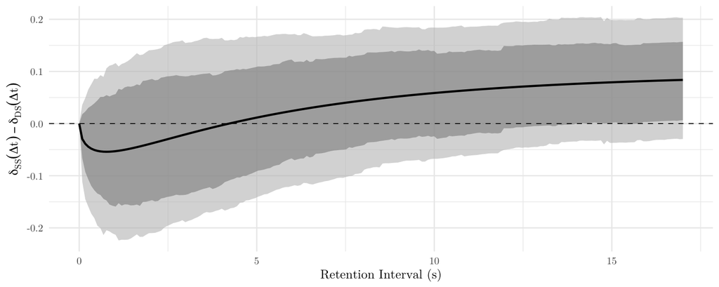

```r
decayContrast <- lapply(deltaT, function(dt) {
  v <- a2 / (a2 + dt^b2) - a1 / (a1 + dt^b1)    # per-draw contrast
  h95 <- bayestestR::hdi(v, ci = 0.95)
  h80 <- bayestestR::hdi(v, ci = 0.80)
  tibble(
    deltaT = dt,
    mean   = mean(v),
    lo80   = h80$CI_low,
    hi80   = h80$CI_high,
    lo95   = h95$CI_low,
    hi95   = h95$CI_high
  )
}) |> bind_rows()

decayContrastFig <- ggplot(decayContrast, aes(x = deltaT)) +
  geom_ribbon(aes(ymin = lo95, ymax = hi95), fill = "grey75", alpha = 0.6) +
  geom_ribbon(aes(ymin = lo80, ymax = hi80), fill = "grey55", alpha = 0.6) +
  geom_hline(yintercept = 0, linetype = "dashed", linewidth = 0.3) +
  geom_line(aes(y = mean), linewidth = 0.8) +
  labs(x = "Retention Interval (s)",
       y = expression(delta[SS](Delta * t) - delta[DS](Delta * t))) +
  theme_paper()

show(decayContrastFig)
```

```r
savePaperFig(decayContrastFig, "exp2_decayContrast.pdf", width = 20, height = 8)
```